# R Markdown for Assignment 3

Sebastian Rincon

2024-04-12

# Analysis Report of the car sales dataset in R for Assignment #3

## by Sebastian Rincon (000881715)

### Dataset source: https://www.kaggle.com/datasets/syedanwarafridi/vehicle-sales-data?resource=download

```r
#Upload Libraries
library(ggplot2)
library(dplyr)
library(tidyr)
library(stats)
library(lubridate)
library(magrittr)
library(psych)
library(tidyverse)
#Upload Dataset
cars <- data.frame(read.csv("car_prices.csv"))
head(cars)
```

```
##   year   make               model       trim  body transmission
## 1 2015    Kia             Sorento         LX   SUV    automatic
## 2 2015    Kia             Sorento         LX   SUV    automatic
## 3 2014    BMW            3 Series 328i SULEV Sedan    automatic
## 4 2015  Volvo                 S60         T5 Sedan    automatic
## 5 2014    BMW 6 Series Gran Coupe       650i Sedan    automatic
## 6 2015 Nissan              Altima      2.5 S Sedan    automatic
##                 vin state condition odometer color interior
## 1 5xyktca69fg566472    ca         5    16639 white    black
## 2 5xyktca69fg561319    ca         5     9393 white    beige
## 3 wba3c1c51ek116351    ca        45     1331  gray    black
## 4 yv1612tb4f1310987    ca        41    14282 white    black
## 5 wba6b2c57ed129731    ca        43     2641  gray    black
## 6 1n4al3ap1fn326013    ca         1     5554  gray    black
##                                               seller   mmr sellingprice
## 1                            kia motors america  inc 20500        21500
## 2                            kia motors america  inc 20800        21500
## 3             financial services remarketing (lease) 31900        30000
## 4                            volvo na rep/world omni 27500        27750
## 5             financial services remarketing (lease) 66000        67000
## 6 enterprise vehicle exchange / tra / rental / tulsa 15350        10900
##                                  saledate
## 1 Tue Dec 16 2014 12:30:00 GMT-0800 (PST)
## 2 Tue Dec 16 2014 12:30:00 GMT-0800 (PST)
## 3 Thu Jan 15 2015 04:30:00 GMT-0800 (PST)
## 4 Thu Jan 29 2015 04:30:00 GMT-0800 (PST)
## 5 Thu Dec 18 2014 12:30:00 GMT-0800 (PST)
## 6 Tue Dec 30 2014 12:00:00 GMT-0800 (PST)
```

```r
#Convert to lower case the model and make column to avoid duplicate categories
cars$make <- tolower(cars$make)
cars$model <- tolower(cars$model)
```

### Let’s create a descriptive analysis of the variables for this dataset:

```r
#descriptive Statistics
describe(cars)
```

```
##               vars      n      mean        sd median   trimmed       mad  min
## year             1 558837   2010.04      3.97   2012   2010.58      2.97 1982
## make*            2 558837     29.93     18.69     26     28.68     22.24    1
## model*           3 558837    380.62    239.28    330    374.15    274.28    1
## trim*            4 558837   1069.80    530.72   1167   1098.90    545.60    1
## body*            5 558837     64.51     20.88     72     69.19      7.41    1
## transmission*    6 558837      1.91      0.38      2      1.98      0.00    1
## vin*             7 558837 275189.50 158894.72 275138 275181.19 204013.17    1
## state*           8 558837     43.18     11.55     41     42.56     13.34    1
## condition        9 547017     30.67     13.40     35     32.10     11.86    1
## odometer        10 558743  68320.02  53398.54  52254  61516.87  45182.24    1
## color*          11 558837     36.31      9.81     36     37.49      8.90    1
## interior*       12 558837      6.48      3.77      4      5.91      1.48    1
## seller*         13 558837   7194.90   4068.20   6693   7173.10   4604.96    1
## mmr             14 558799  13769.38   9679.97  12250  12729.51   8265.49   25
## sellingprice    15 558825  13611.36   9749.50  12100  12573.79   8376.69    1
## saledate*       16 558837   1909.13   1001.64   1948   1921.44   1249.83    1
##                  max  range  skew kurtosis     se
## year            2015     33 -1.18     1.01   0.01
## make*             67     66  0.49    -0.98   0.03
## model*           852    851  0.24    -1.04   0.32
## trim*           1964   1963 -0.44    -0.77   0.71
## body*             88     87 -1.82     2.10   0.03
## transmission*      5      4 -0.90     3.40   0.00
## vin*          550298 550297  0.00    -1.20 212.55
## state*            64     63  0.33    -1.41   0.02
## condition         49     48 -0.83    -0.22   0.02
## odometer      999999 999998  1.84    13.55  71.44
## color*            47     46 -1.74     4.14   0.01
## interior*         18     17  1.16     0.63   0.01
## seller*        14263  14262  0.09    -1.12   5.44
## mmr           182000 181975  2.00    11.44  12.95
## sellingprice  230000 229999  1.95    11.11  13.04
## saledate*       3767   3766 -0.07    -1.00   1.34
```

We can observe that the the mean price for a vehicle in the US using the trimmed mean that provides more precise calculations is around 12.579 which is actually pretty close to the MMR (Market value) having an average price of 12.729. In terms of mileage the average is around 61.516 miles and if we link this value with the average year of the car which is 2010, we could say that this is a dealer that handles cars in good condition, with low miles due to that the majority of the cars don’t have more than 15 years.

##Now let’s change the format of the sale date to make it proper for data analysis

```r
# Convert saledate to datetime and add as a new column
cars$date <- mdy_hms(cars$saledate)
#remove the old column
cars <- subset(cars, select = -saledate)
```

## the next step is creating some graphics to show the relationships between variables

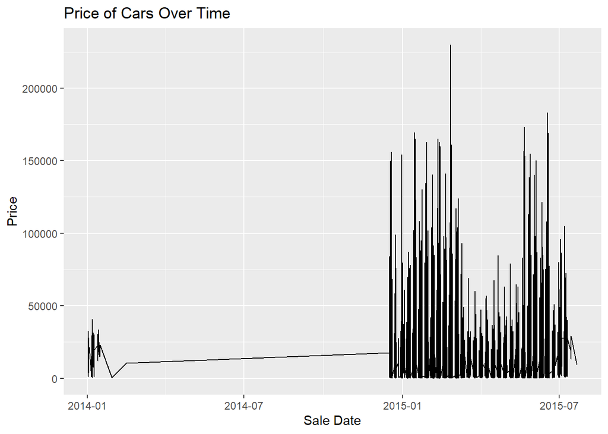

```r
ggplot(cars, aes(x = date, y = sellingprice)) +
  geom_line() +
  labs(title = "Price of Cars Over Time", x = "Sale Date", y = "Price")
```

### explore the sales distribution by vehicle make and model:

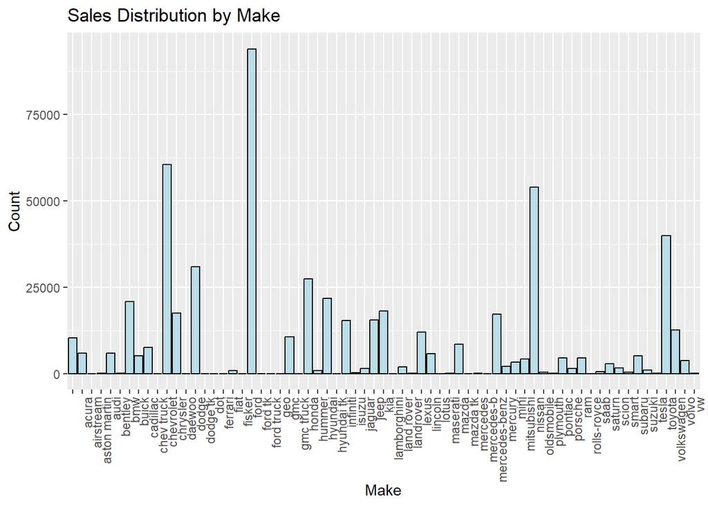

```r
# Bar plot for make
ggplot(cars, aes(x = make)) +
  geom_bar(fill = "lightblue", color = "black", alpha = 0.8) +
  labs(title = "Sales Distribution by Make", x = "Make", y = "Count")+
  theme(axis.text.x = element_text(angle =90, hjust = 1))
```

```r
brand_counts <- table(cars$make)
brand_counts <- sort(brand_counts, decreasing = TRUE)
brand_counts
```

```
##
##          ford     chevrolet        nissan        toyota         dodge
##         93997         60587         54017         39966         30955
##         honda       hyundai           bmw           kia      chrysler
##         27351         21836         20793         18084         17485
## mercedes-benz          jeep      infiniti    volkswagen         lexus
##         17141         15483         15305         12605         11980
##           gmc                       mazda      cadillac         acura
##         10638         10301          8508          7629          5926
##          audi       lincoln         buick        subaru           ram
##          5877          5786          5121          5103          4574
##       pontiac    mitsubishi         volvo          mini        saturn
##          4524          4257          3788          3224          2841
##       mercury    land rover         scion        jaguar       porsche
##          2023          1864          1687          1420          1402
##        suzuki          fiat        hummer          saab         smart
##          1078           865           805           484           396
##    oldsmobile         isuzu      maserati       bentley      mercedes
##           384           204           136           116            70
##     landrover      plymouth  aston martin            vw         tesla
##            27            27            25            24            23
##       ferrari           geo   rolls-royce     gmc truck        fisker
##            19            19            17            11             9
##   lamborghini        daewoo    ford truck    mercedes-b     airstream
##             4             3             3             2             1
##    chev truck      dodge tk           dot       ford tk    hyundai tk
##             1             1             1             1             1
##         lotus      mazda tk
##             1             1
```

### we can observe that Ford is the leading brand with 93.997 cars sold, followed by Chevy with 60.587 and nissan with 54.017

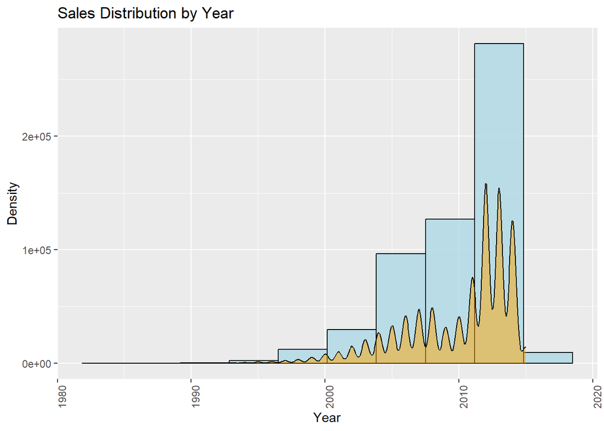

```r
# Histogram and density plots for year
ggplot(cars, aes(x = year)) +
  geom_histogram(fill = "lightblue", color = "black", alpha = 0.8, bins = 10) +
  geom_density(aes(y = ..count..), fill = "orange", alpha = 0.5) +
  labs(title = "Sales Distribution by Year", x = "Year", y = "Density")+
  theme(axis.text.x = element_text(angle =90, hjust = 1))
```

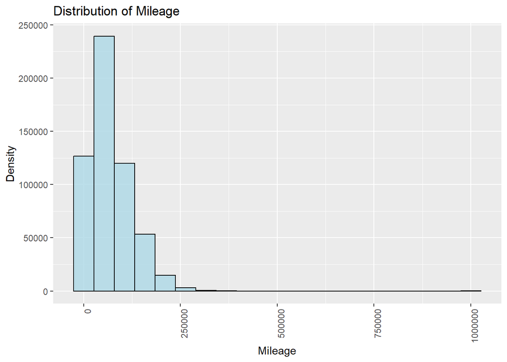

```r
# Histogram and density plots for mileage
ggplot(cars, aes(x = odometer)) +
  geom_histogram(fill = "lightblue", color = "black", alpha = 0.8, bins = 20) +
  geom_density(aes(y = ..count..), fill = "orange", alpha = 0.5) +
  labs(title = "Distribution of Mileage", x = "Mileage", y = "Density") +
  theme(axis.text.x = element_text(angle =90, hjust = 1))
```

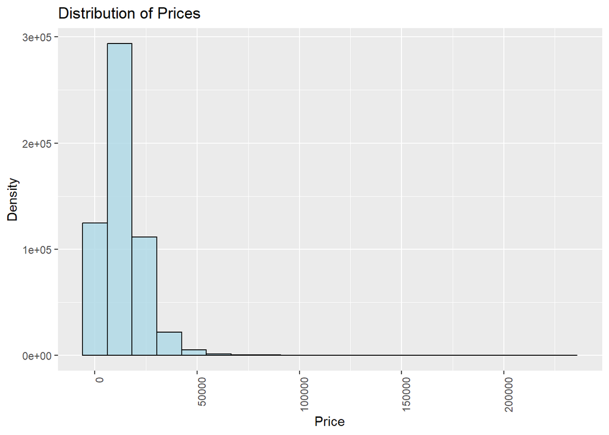

```r
# Histogram and density plots for price
ggplot(cars, aes(x = sellingprice)) +
  geom_histogram(fill = "lightblue", color = "black", alpha = 0.8, bins = 20) +
  geom_density(aes(y = ..count..), fill = "orange", alpha = 0.5) +
  labs(title = "Distribution of Prices", x = "Price", y = "Density")+
  theme(axis.text.x = element_text(angle =90, hjust = 1))
```

[output not shown]